# Correlation and Simple Linear Regression

The degree to which the points in a scatterplot tend to cluster around a line reflects the strength of the linear relationship between x and y. The visual impression of a scatterplot can be misleading in this regard, because changing the scale of the axes can make the clustering appear tighter or looser. For this reason, we define the correlation coefficient, which is a numerical measure of the strength of the linear relationship between two variables. The correlation coefficient is usually denoted by the letter r.

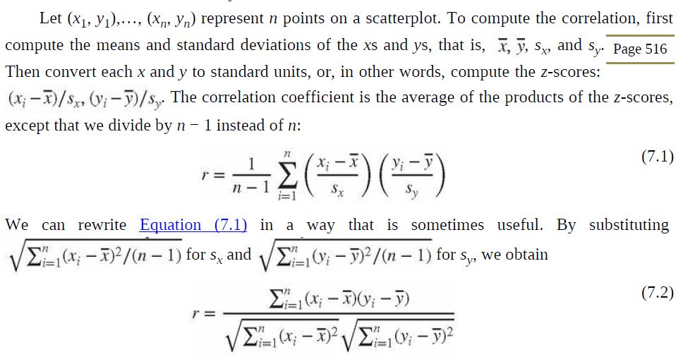

In principle, the correlation coefficient can be calculated for any set of points. In many cases, the points constitute a random sample from a population of points. In these cases the correlation coefficient is often called the sample correlation, and it is an estimate of the population correlation.

Finally, a bit of terminology: Whenever r ≠ 0, x and y are said to be correlated. If r = 0, x and y are said to be uncorrelated.

For children, vocabulary size is strongly correlated with shoe size. However, learning new words does not cause feet to grow, nor do growing feet cause one’s vocabulary to increase. There is a third factor, namely age, that is correlated with both shoe size and vocabulary. Older children tend to have both larger shoe sizes and larger vocabularies, and this results in a positive correlation between vocabulary and shoe size. This phenomenon is known as confounding. Confounding occurs when there is a third variable that is correlated with both of the variables of interest, resulting in a correlation between them.

To restate this example in more detail: Individuals with larger ages tend to have larger shoe sizes. Individuals with larger ages also tend to have larger vocabularies. It follows that individuals with larger shoe sizes will tend to have larger vocabularies. In other words, because both shoe size and vocabulary are positively correlated with age, they are positively correlated with each other.

Do not extrapolate a fitted line (such as the least-squares line) outside the range of the data. The linear relationship may not hold there.

[figure not shown]

The single best diagnostic for least-squares regression is a plot of residuals ei versus fitted values ŷi, sometimes called a residual plot.

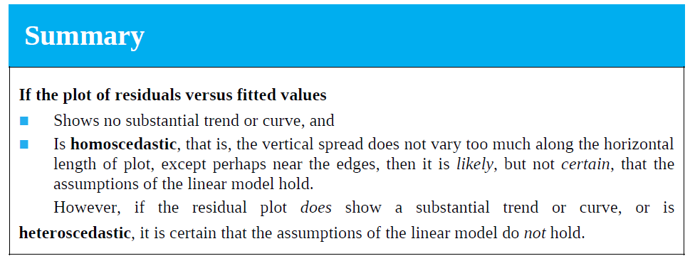